# An example to compute Fisher’s exact p-value and CI

Suppose we conduct experiment with complete randomization, obtain the assignment $W = (1,1,0,1,1,0,0,1)$, and the observed outcome for all units are $Y^{\text{obs}} = (12, 7, 2, 7, 6, 6, 2, 7)$.

## 1. Test for the sharp null hypothesis of no individual causal effect

- Impute all the missing potential outcomes under the sharp null.

```r
W <- c(1,1,0,1,1,0,0,1)

Yobs <- c(12, 7, 2, 7, 6, 6, 2, 7)
n <- length(W)
n1 <- sum(W)

# Under the sharp null of no causal effect
Y0 <- Y1 <- Yobs
data <- data.frame(W = W, Y0 = Y0, Y1 = Y1, Yobs = Yobs)
print(data)
```

```
##   W Y0 Y1 Yobs
## 1 1 12 12   12
## 2 1  7  7    7
## 3 0  2  2    2
## 4 1  7  7    7
## 5 1  6  6    6
## 6 0  6  6    6
## 7 0  2  2    2
## 8 1  7  7    7
```

- Calculate the distribution of the difference-in-means estimator $\hat{\tau}$ under the sharp null

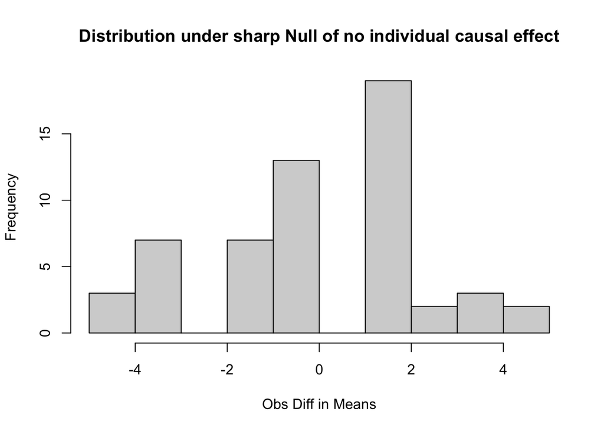

```r
## observed test statistics value, here you can also replace the difference-in-means estimator with other types of test statistics
tau_obs <- mean(Yobs[W==1]) - mean(Yobs[W==0])


### get all possible assignments
treated_all <- combn(n, n1)
permuted_assignments <- apply(treated_all, 2, function(idx) {
  permuted_treatment <- rep(0, n)
  permuted_treatment[idx] <- 1
  return(permuted_treatment)
})

# calculate test statistics for all permutations
tau_rand <- apply(permuted_assignments, 2, function(w) {
    mean(data$Y1[w==1]) - mean(data$Y0[w==0])
})

hist(tau_rand, breaks = 10, main="Distribution under sharp Null of no individual causal effect", xlab="Obs Diff in Means")
```

- How extreme is the observed difference-in-means estimator $\hat{\tau}^{\text{obs}}$? What is the probability of having at least as extreme as the observed one?

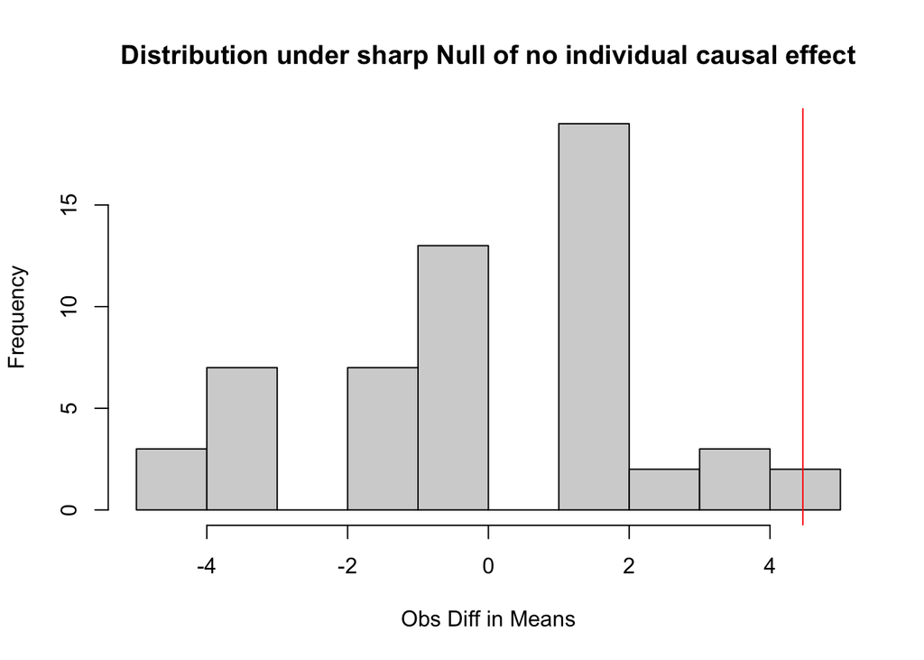

```r
hist(tau_rand, breaks = 10, main="Distribution under sharp Null of no individual causal effect", xlab="Obs Diff in Means")
abline(v = tau_obs, col = "red")
```

```r
## calculate p-value
p <- mean(abs(tau_rand) >= abs(tau_obs))
print(p)
```

```
## [1] 0.03571429
```

# 2. Test for the sharp null hypothesis that the individual treatment effects are all 1.

- Impute the missing potential outcomes

```r
# Under the sharp null of causal effect is 1
data$Y0[data$W == 1] <-  data$Yobs[data$W == 1] - 1
data$Y1[data$W == 0] <- data$Yobs[data$W == 0] + 1

print(data)
```

```
##   W Y0 Y1 Yobs
## 1 1 11 12   12
## 2 1  6  7    7
## 3 0  2  3    2
## 4 1  6  7    7
## 5 1  5  6    6
## 6 0  6  7    6
## 7 0  2  3    2
## 8 1  6  7    7
```

- Calculate Fisher’s exact p-value using the test statistics $\bar Y_1 - \bar Y_0 - 1$

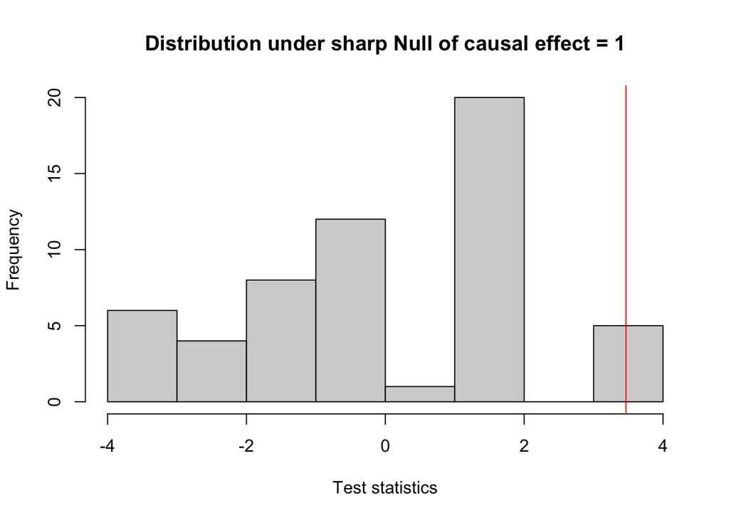

```r
## recompute the distribution of Y1[w = 1] - Y0[w = 0] - 1
tau_obs <- mean(Yobs[W==1]) - mean(Yobs[W==0]) - 1
tau_rand <- apply(permuted_assignments, 2, function(w) {
    mean(data$Y1[w==1]) - mean(data$Y0[w==0]) - 1
})
hist(tau_rand, breaks = 10, main="Distribution under sharp Null of causal effect = 1", xlab="Test statistics")
abline(v = tau_obs, col = "red")
```

```r
p = mean(abs(tau_rand) >= abs(tau_obs))
print(p)
```

```
## [1] 0.1964286
```

# 3. Compute confidence interval for the average treatment effect

- Calculate the randomization $p$-value for a sequence of sharp null hypotheses of additive treatment effects of $\{-15,-14, \ldots, 14,15\}$, and get the $95\%$ confidence interval

```r
# need to write a function that compute p-value for any tau
getPvalue <- function(tau, data) {
  tau_obs <- mean(data$Yobs[data$W==1]) - mean(data$Yobs[data$W==0]) - tau

  data$Y0[data$W == 1] <-  data$Yobs[data$W == 1] - tau
  data$Y1[data$W == 0] <- data$Yobs[data$W == 0] + tau

  ## recompute the distribution of Y1[w = 1] - Y0[w = 0] - tau
  tau_rand <- apply(permuted_assignments, 2, function(w) {
    mean(data$Y1[w==1]) - mean(data$Y0[w==0]) - tau
})
  p = mean(abs(tau_rand) >= abs(tau_obs))
  return(p)
}

## Compute the p-value for a seqeunce of tau
tau_seq <- seq(-15, 15, by = 1)
pvalue_seq <- sapply(tau_seq, getPvalue, data)
names(pvalue_seq) <- tau_seq
print(pvalue_seq, digits = 3)
```

```
##    -15    -14    -13    -12    -11    -10     -9     -8     -7     -6     -5
## 0.0179 0.0179 0.0179 0.0179 0.0179 0.0179 0.0179 0.0179 0.0179 0.0179 0.0179
##     -4     -3     -2     -1      0      1      2      3      4      5      6
## 0.0179 0.0179 0.0179 0.0179 0.0357 0.1964 0.2143 0.5179 0.8393 0.9107 0.4464
##      7      8      9     10     11     12     13     14     15
## 0.1964 0.1071 0.1071 0.0536 0.0179 0.0179 0.0179 0.0179 0.0179
```

```r
## find a better lower bound
tau_seq1 <- seq(0, 1, by = 0.1)
pvalue_seq1 <- sapply(tau_seq1, getPvalue, data)
names(pvalue_seq1) <- tau_seq1
print(pvalue_seq1, digits = 3)
```

```
##      0    0.1    0.2    0.3    0.4    0.5    0.6    0.7    0.8    0.9      1
## 0.0357 0.0357 0.0357 0.0357 0.0357 0.0357 0.0357 0.0357 0.0357 0.0357 0.1964
```

```r
## find a better upper bound

tau_seq2 <- seq(10, 11, by = 0.1)
pvalue_seq2 <- sapply(tau_seq2, getPvalue, data)
names(pvalue_seq2) <- tau_seq2
print(pvalue_seq2, digits = 3)
```

```
##     10   10.1   10.2   10.3   10.4   10.5   10.6   10.7   10.8   10.9     11
## 0.0536 0.0179 0.0179 0.0179 0.0179 0.0179 0.0179 0.0179 0.0179 0.0179 0.0179
```

# 4. Monte Carlo method when the same size is large

- When the sample size is large, it is impossible to enumerate all possible randomizations. How would you get an approximation for the randomization test $p$-value?

```r
## Say we want M = 10000 random samples of the treatment assignments
### get M random samples of possible assignments
getPvalueMC <- function(data, tau, M = 10000) {
  tau_obs <- mean(data$Yobs[data$W==1]) - mean(data$Yobs[data$W==0]) - tau

  data$Y0[data$W == 1] <-  data$Yobs[data$W == 1] - tau
  data$Y1[data$W == 0] <- data$Yobs[data$W == 0] + tau

  ## randomly sample the treatment assignment vector following the complete randomization mechanism

  set.seed(0)
  tau_rand <- sapply(1:M, function(i) {
    w <- sample(data$W)
    return(mean(data$Y1[w==1]) - mean(data$Y0[w==0]) - tau)
  })
  p = mean(abs(tau_rand) >= abs(tau_obs))
  return(p)
}

getPvalueMC(data, 0, 10000)
```

```
## [1] 0.0332
```